# 2D Cochlear Models

by Liu-Jie Ren

[figure not shown]

**Notations**

- Coordinates $x$ and $y$
- Field variables
  - $p(x,y,t)$ - Pressure of the fluid
  - $\vec{v}(x,y,t)$ - Fluid velocity (vector in $x, y$ direction)
- Parameters
  - $\rho$ - fluid density
  - $\mu$ - fluid viscosity
  - $c$ - sound speed in fluid
- Basilar membrane
  - $\eta(x,t)$ - BM displacement
  - $k(x)$ - BM stiffness
  - $r(x)$ - BM damping
  - $m(x)$ - BM mass
- subscriptions: we use the subscript $v$ for scala vestibula, $t$ for scala tympani.

## Control Equations for Fluid in General

Firstly we assume the cochlear fluid is a water-like Newtonian fluid controled by the Navier-Stokes equations. The fluid is assumed to be compressible for now.

The NS equations for compressible fluid are $$\begin{align} & \mathrm{Continuty:\quad} \frac{\partial\rho}{\partial t}+\nabla\left(\rho\vec{v}\right)=0 \\ & \mathrm{Momentum: \quad} \rho\left(\frac{\partial\vec{v}}{\partial t}+\vec{v}\cdot\nabla\vec{v}\right) =-\nabla p+\mu\nabla^2\vec{v}+\frac{1}{3}\mu\nabla(\nabla\cdot\vec{v})+\rho\vec{g} \end{align}$$

**Simplifications**

- We assume no body force so that $\vec{g}=0$,
- No convective term so that $\vec{v}\cdot\nabla\vec{v}=0$,thus the momentum equation becomes $\displaystyle \rho\frac{\partial\vec{v}}{\partial t} =-\nabla p+\mu\nabla^2\vec{v}+\frac{1}{3}\mu\nabla(\nabla\cdot\vec{v})$

For different assumptions, we can make different forms

**Acoustic compressible and viscous** For acoutic flow, we assume $\rho$ is nearly a constant and $\displaystyle \frac{\partial p}{\partial \rho} = c^2$, $\displaystyle\frac{\partial\rho}{\partial t}=\frac{1}{c^2}\frac{\partial p}{\partial t}$, $$\begin{align} &\frac{1}{c^2}\frac{\partial p}{\partial t}+\nabla\left(\rho\vec{v}\right)=0 \rightarrow \frac{1}{c^2}\frac{\partial p}{\partial t}+\rho\nabla\vec{v}=0\\ &\rho\frac{\partial\vec{v}}{\partial t}=-\nabla p+\mu\nabla^2\vec{v}+\frac{1}{3}\mu\nabla(\nabla\cdot\vec{v}) \end{align}$$ by assuming $$\vec{v}\cdot\nabla\rho\approx 0$$

**Incompressible and viscous**

If the fluid is incompressible, then $\partial\rho/\partial t=0$ and $\nabla\vec{v}=0$, thus $$ \begin{align} &\nabla\vec{v} = 0 \\ &\rho\frac{\partial\vec{v}}{\partial t}=-\nabla p+\mu\nabla^2\vec{v} \end{align}$$

**Acoustic compressible and invicid**

If the fluid in invicid, then $\nu=0$, thus $$ \begin{align} &\frac{1}{c^2}\frac{\partial p}{\partial t}+\nabla\left(\rho\vec{v}\right)=0 \rightarrow \frac{1}{c^2}\frac{\partial p}{\partial t}+\rho\nabla\vec{v}=0 \rightarrow \frac{1}{c^2}\frac{\partial^2p}{\partial t^2}+\rho\frac{\partial \nabla\vec{v}}{\partial t}=0 \\ &\rho\frac{\partial\vec{v}}{\partial t}=-\nabla p \rightarrow \rho\nabla\left(\frac{\partial\vec{v}}{\partial t}\right)=-\nabla^2 p \end{align}$$

Thus $$ \frac{1}{c^2}\frac{\partial p}{\partial t}-\nabla^2 p = 0$$

**Incompressible and invicid** $$ \begin{align} &\nabla\cdot\vec{v} = 0 \\ &\rho\frac{\partial\vec{v}}{\partial t}=-\nabla p \end{align}$$ Thus $$\nabla^2 p = 0$$

For the fluid field, if we use the **viscous** assumption, we should solve the pressure and displacement/velocity field together, as shown in Cheng (2008) and Ren (2018). The mixed finite element method could be a little bit complicated (the researchers have to deal with the stability), we would discuss it later.

However, if we use the **invicid** assumption, whether compressible or incompressible (as most models used), we can solve the fluid pressure field only. For incompressilbe flow, $$\nabla^2 p = 0$$ and for compressilbe acoutic flow, $$\frac{1}{c^2}\frac{\partial p}{\partial t} - \nabla^2 p = 0$$

**Boundary conditions** For the fluid pressure field, we have 2 types of boundary conditions.

- Dirichlet B.C.
  - the fluid pressure should be a given, $p = \bar{p}$
- Neumann B.C.
  - the normal fluid displacement/velocity is given, since $\rho\partial\vec{v_n}/\partial t=\rho \vec{a}_n=-\nabla p\cdot\vec{n}$
  - $\nabla p \cdot \vec{n} = 0$ for wall
  - $\nabla p \cdot \vec{n} = -\rho a_n $ for given normal accelaration

**Coupling with the BM**

Two conditions should be satisfied

- Displacement/velocity
  - thus $\nabla p\cdot\vec{n}=\rho a_n$ where $a_n$ is decided by the BM movement
- Force
  - $ m\ddot{\eta}+r\dot{\eta}+k\eta = f(p)$ the movement of BM is driven by the fluid force

## Symmetrical box model (2D)

Early 2d cochlear models made geometrical simplication for the cochlea. Here we start with Neely(1981)'s model.

[figure not shown]

### Control equations

In Neely's model, the fluid is assumed to be incompressible and invicid, thus $$\nabla\cdot\vec{v}_v=0,\qquad \rho\frac{\partial\vec{v}_v}{\partial t}=-\nabla p_v\qquad x\in[0,L],y\in[0,H]$$ $$\nabla\cdot\vec{v}_t=0,\qquad \rho\frac{\partial\vec{v}_t}{\partial t}=-\nabla p_t\qquad x\in[0,L],y\in[0,-H]$$ Assume that $\vec{v}(x,y)=\vec{v}_v(x,y)-\vec{v}_t(x,-y)$ and $p(x,y)=p_v(x,y)-p_t(x,-y)$

**Governing equations**

For compressible flow: $\frac{1}{c^2}\frac{\partial p}{\partial t}-\nabla^2p=0$; for incompressible flow: $\nabla^2p=0$.

**Boundary conditions**

- At the upper wall, $\vec{v}_v\cdot\vec{n}=0$; at the lower wall $\vec{v}_t\cdot\vec{n}=0$, thus $\vec{v}\cdot\vec{n}=0$, and $\boxed{\nabla p\cdot\vec{n}=0}$ or simply $\boxed{\partial p/\partial y=0}$
- At the base, $\nabla p_v\cdot\vec{n}=-\rho\dot{v}_v\cdot\vec{n} = \rho \ddot{u}_{st}$, $\nabla p_t\cdot\vec{n}=-\rho\dot{v}_t\cdot\vec{n} = \rho \ddot{u}_{rw}$, thus $\boxed{ \nabla p\cdot\vec{n}=2\rho\ddot{u}_{st}}$ or $\boxed{ \partial p/\partial x=-2\rho\ddot{u}_{st}}$
- For the BM, we have $\nabla p_v\cdot\vec{n}=-\rho\dot{v}_v\cdot\vec{n}= \rho\ddot{\eta}$ and $\nabla p_t\cdot\vec{n}=-\rho\ddot{\eta}$, thus $\boxed{ \nabla p\cdot\vec{n} = 2\rho\ddot{\eta} }$ or $\boxed{\partial p/\partial y=-2\rho\ddot{\eta}}$

**Basilar Membrane** $m(x)\ddot{\eta}(x)+r(x)\cdot{\eta}(x)+k(x)\eta(x) = p_t(x,y=0)-p_v(x,y=0)=-p(x)$

### Frequency domain solution

Assume that $p(x,y,t) = P(x,y)\exp(j\omega t)$, then

**Control Equation** $$ -\frac{j\omega}{c^2}P+\nabla^2 P = 0 \quad \mathrm{for~compressible~flow} \\ \nabla^2 P = 0 \quad \mathrm{for~incompressible~flow} $$ **Boundary Domain**

- For the upper wall, $\frac{\partial P}{\partial y}=0$
- For the left wall, $\frac{\partial P}{\partial x} = 2\rho\omega^2 U_{st}$
- For the right wall, $P = 0$
- For the bottom wall (BM), $\frac{\partial P}{\partial y}=2\rho\omega^2\eta$
- and $-P=Z(x)\eta$, thus $\frac{\partial P}{\partial y}=\frac{-2\rho\omega^2}{Z(x)}P$

**Finite Difference Method** The solutions were given using Neely's finite difference method (1981).

> Neely S T. Finite difference solution of a two‐dimensional mathematical model of the cochlea[J]. The Journal of the Acoustical Society of America, 1981, 69(5): 1386-1393.

[figure not shown]

We divide the fluid domain into $M\times N$ grids. Each grid is represented by a unique pair $(i,j)$, or a unique number $(N-1)\times j+i$

```matlab
%%file cochlea_model_2d_passive_neely.m
function [P,nod,ele]=cochlea_model_2d_passive_neely(freq,Us)
    M = 257; N = 17;
    L = 0.035; H = 0.001;
    rho = 1000; c = 1430;
    x = linspace(0,L,M)';
    m = 1.5;
    r = 2000;
    k = 1e10*exp(-200*x);
    grids = reshape(1:M*N,M,N);
    dx = L/(M-1); dxx = 1/(dx*dx);
    dy = H/(N-1); dyy = 1/(dy*dy);

    w = 2*pi*freq;
    Z = k-m*w*w+1i*w*r;
    idx = zeros(5*M*N,1);
    jdx = zeros(5*M*N,1);
    tmp = zeros(5*M*N,1);
    flag = 0;

    FF = zeros(M*N,1);
    % the domain | Pxx+Pyy-jw/c/c*P=0
    for ii = 2:M-1
        for jj = 2:N-1
            pc = grids(ii,jj);
            pn = grids(ii,jj+1);
            ps = grids(ii,jj-1);
            pw = grids(ii-1,jj);
            pe = grids(ii+1,jj);
            idx(flag+1:flag+5) = [pc pc pc pc pc];
            jdx(flag+1:flag+5) = [pn ps pw pe pc];
            % tmp(flag+1:flag+5) = [dyy,dyy,dxx,dxx,-2*dxx-2*dyy-1i*w/c/c]; %compressible
            tmp(flag+1:flag+5) = [dyy,dyy,dxx,dxx,-2*dxx-2*dyy]; %incompressible
            flag = flag+5;
        end
    end
    % upper | Py=0
    for ii = 1:M
        pc = grids(ii,N);
        ps = grids(ii,N-1);
        idx(flag+1:flag+2) = [pc,pc];
        jdx(flag+1:flag+2) = [pc,ps];
        tmp(flag+1:flag+2) = [1,-1]/dy;
        flag = flag + 2;
    end
    % bottom | Py + 2\rho*w*w/Z * P = 0
    for ii = 1:M
        pc = grids(ii,1);
        pn = grids(ii,2);
        idx(flag+1:flag+2) = [pc,pc];
        jdx(flag+1:flag+2) = [pc,pn];
        tmp(flag+1:flag+2) = [-1/dy+2*rho*w*w/Z(ii),1/dy];
        flag = flag + 2;
    end
    % left | Px = 2 \rho w*w Us
    for jj = 2:N-1
        pc = grids(1,jj);
        pe = grids(2,jj);
        idx(flag+1:flag+2) = [pc,pc];
        jdx(flag+1:flag+2) = [pc,pe];
        tmp(flag+1:flag+2) = [-1,1]/dx;
        FF(pc) = 2*rho*w*w*Us;
        flag = flag + 2;
    end
    % right| P = 0
    for jj = 2:N-1
        pc = grids(M,jj);
        idx(flag+1) = [pc];
        jdx(flag+1) = [pc];
        tmp(flag+1) = [1]/dx;
        FF(pc) = 0;
        flag = flag + 1;
    end
    KK = sparse(idx(1:flag),jdx(1:flag),tmp(1:flag),M*N,M*N);
    P = KK\FF;
    [nod,ele] = createGridMesh(M,N,L,H);
    pressure = P(grids(1:M,1));
    displacement = -pressure./Z;

    figure(1);
    subplot(2,2,1); hold on; grid on;
    plot(x, 20*log10(abs(pressure)), 'k-', 'linewidth', 2);
    xlabel('distance from the stapes, x (m)');
    ylabel('pressure difference in dB');
    set(gca,'xlim',[0,L],'ylim',[70,200]);

    subplot(2,2,2); hold on; grid on;
    plot(x, 20*log10(abs(displacement/Us)), 'k-', 'linewidth', 2);
    xlabel('distance from the stapes, x (m)');
    ylabel('BM displacement re stapes in dB');
    set(gca,'xlim',[0,L],'ylim',[-45,20]);

    subplot(2,2,3); hold on; grid on;
    plot(x, unwrap(angle(pressure))/pi, 'k-', 'linewidth', 2);
    xlabel('distance from the stapes, x (m)');
    ylabel('pressure phase, \pi');
    set(gca,'xlim',[0,L]);

    subplot(2,2,4); hold on; grid on;
    plot(x, unwrap(angle(displacement))/pi, 'k-', 'linewidth', 2);
    xlabel('distance from the stapes, x (m)');
    ylabel('disp. phase, \pi');
    set(gca,'xlim',[0,L]);
end

function [nod,ele] = createGridMesh(M,N,L,H)
    dx = L/(M-1);
    dy = H/(N-1);
    nod = zeros(M*N,2);
    kk = 1;
    for jj = 1:N
        for ii = 1:M
            nod(kk,:) = [dx*(ii-1) dy*(jj-1)];
            kk = kk + 1;
        end
    end
    ele = zeros((M-1)*(N-1),4);
    kk = 1;
    for jj = 1:N-1
        for ii = 1:M-1
            n1 = M*(jj-1)+ii;
            n2 = n1+1;
            n3 = n2+M;
            n4 = n3-1;
            ele(kk,:) = [n1,n2,n3,n4];
            kk = kk + 1;
        end
    end
end
```

```
Created file 'C:\Users\RenLi\__model_cochlea\cochlea_model_2d_passive_neely.m'.
```

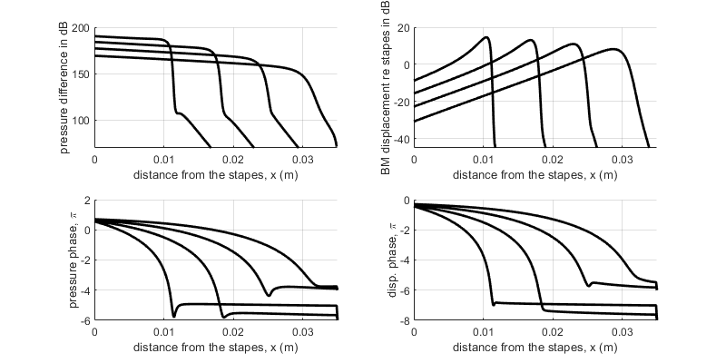

```matlab
%plot inline --size 800,400
cochlea_model_2d_passive_neely(500,1);
[P,nod,ele]=cochlea_model_2d_passive_neely(1000,1);
cochlea_model_2d_passive_neely(2000,1);
cochlea_model_2d_passive_neely(4000,1);
```

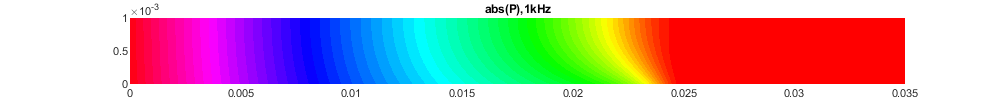

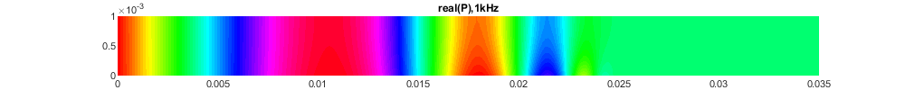

```matlab
%plot inline --size 1000,100
figure(1); patch('Faces',ele,'Vertices',nod,'FaceVertexCData',real(P),'FaceColor','interp','edgecolor','none');
title('real(P),1kHz'); colormap('hsv')
figure(2); patch('Faces',ele,'Vertices',nod,'FaceVertexCData',abs(P),'FaceColor','interp','edgecolor','none');
title('abs(P),1kHz'); colormap('hsv')
```

### Time-Domain Solution

**Governing equations**

For compressible flow: $-\frac{1}{c^2}\frac{\partial p}{\partial t}+\nabla^2p=0$; for incompressible flow: $\nabla^2p=0$.

**Boundary conditions**

- At the upper wall, $\boxed{\partial p/\partial y=0}$
- For the BM, $\boxed{\partial p/\partial y=-2\rho\ddot{\eta}}$
- At the base, $\boxed{ \partial p/\partial x=-2\rho\ddot{u}_{st}}$
- At right, $\boxed{p=0}$

**Basilar Membrane** $m(x)\ddot{\eta}(x)+r(x)\cdot{\eta}(x)+k(x)\eta(x) =-p(x)$

$$ \left[ \begin{array}{cc} M_{pp} & M_{p\eta} \\ M_{\eta p} & M_{\eta\eta}\end{array}\right] \cdot\left\{\begin{array}{c} \ddot{P} \\ \ddot{\eta} \end{array}\right\} + \left[ \begin{array}{cc} R_{pp} & R_{p\eta} \\ R_{\eta p} & R_{\eta\eta}\end{array}\right] \cdot\left\{\begin{array}{c} \dot{P} \\ \dot{\eta} \end{array}\right\} + \left[ \begin{array}{cc} K_{pp} & K_{p\eta} \\ K_{\eta p} & K_{\eta\eta}\end{array}\right] \cdot\left\{\begin{array}{c} {P} \\ {\eta} \end{array}\right\} =\left\{\begin{array}{c} F_{P} \\ F_{\eta} \end{array}\right\}$$

Here $$M_{pp}=0, \quad M_{p\eta}=0, \quad M_{\eta p}=0, \quad M_{\eta\eta}=mI \\ R_{pp}=0 \mathrm{~incompressible}, R_{pp}=-\frac{1}{c^2}I \mathrm{~compressible}, \quad R_{p\eta}=0,\quad R_{\eta p}=0,\quad R_{\eta\eta} = rI \\ K_{pp}=\mathrm{Lapalce~term}, \quad K_{p\eta}=0, \quad K_{\eta p}=1\textrm{~for~some~points},\quad K_{\eta\eta}=kI $$ and the boundary conditions should be implemented.

$$ \left[ \begin{array}{cc} 0 & M^*_{p\eta} \\ 0 & M_{\eta\eta}\end{array}\right] \cdot\left\{\begin{array}{c} \ddot{P} \\ \ddot{\eta} \end{array}\right\} + \left[ \begin{array}{cc} R_{pp} & 0 \\ 0 & R_{\eta\eta}\end{array}\right] \cdot\left\{\begin{array}{c} \dot{P} \\ \dot{\eta} \end{array}\right\} + \left[ \begin{array}{cc} K_{pp} & 0 \\ K_{\eta p} & K_{\eta\eta}\end{array}\right] \cdot\left\{\begin{array}{c} {P} \\ {\eta} \end{array}\right\} =\left\{\begin{array}{c} F_{P} \\ F_{\eta} \end{array}\right\}$$

where $M^*_{p\eta}$ is from the boundary condition $\partial p/\partial y=-2\rho\ddot{\eta}$.

```matlab
%%file cochlea_model_2d_passive_neely_time.m
function cochlea_model_2d_passive_neely_time(t,Ast,plotstyle)
    M = 257; N = 17;
    L = 0.035; H = 0.001;
    rho = 1000; c = 1430;
    x = linspace(0,L,M)';
    m = 1.5;
    r = 2000;
    k = 1e10*exp(-200*x);
    grids = reshape(1:M*N,M,N);
    dx = L/(M-1); dxx = 1/(dx*dx);
    dy = H/(N-1); dyy = 1/(dy*dy);
    [nod,ele] = createGridMesh(M,N,L,H);
    % m \ddot{\eta} + r\dot{\eta} + k\eta + 2p = 0
    Fp  = zeros(M*N,1);
    Fe  = zeros(M,1);
    Mee = sparse(1:M,1:M,m.*ones(M,1),M,M);
    Mep = sparse(M,M*N);
    Ree = sparse(1:M,1:M,r.*ones(M,1),M,M);
    Rep = sparse(M,M*N);
    Kee = sparse(1:M,1:M,k.*ones(M,1),M,M);
    Kep = sparse(1:M,1:M,2.*ones(M,1),M,M*N);
    Mpp = sparse(M*N,M*N);
    Rpe = sparse(M*N,M);
    Kpe = sparse(M*N,M);
    % \nabla^2 p - 1/c/c*\dot{p} = 0 ==> Kpp and Rpp for inner nodes
    Kppidx = zeros(5*M*N,1); Kppjdx = Kppidx; Kpptmp = Kppidx; Kppflag = 0;
    Rppidx = zeros(5*M*N,1); Rppjdx = Rppidx; Rpptmp = Rppidx; Rppflag = 0;
    for ii = 2:M-1
        for jj = 2:N-1
            pc = grids(ii,jj); pn = grids(ii,jj+1); ps = grids(ii,jj-1);
            pw = grids(ii-1,jj); pe = grids(ii+1,jj);
            Kpplist = Kppflag+1:Kppflag+5;
            Kppidx(Kpplist) = [pc pc pc pc pc];
            Kppjdx(Kpplist) = [pn ps pw pe pc];
            Kpptmp(Kpplist) = [dyy dyy dxx dxx -2*dxx-2*dyy];
            Kppflag = Kppflag + 5;
            Rpplist = Rppflag+1;
            Rppidx(Rpplist) = [pc];
            Rppjdx(Rpplist) = [pc];
            Rpptmp(Rpplist) = -1/c/c;
        end
    end
    % Upper nodes dp/dy = 0 ===> only affects Kpp
    for ii = 1:M
        pc = grids(ii,N); ps = grids(ii,N-1);
        Kpplist = Kppflag+1:Kppflag+2;
        Kppidx(Kpplist) = [pc pc];
        Kppjdx(Kpplist) = [pc ps];
        Kpptmp(Kpplist) = [-1  1]/dy;
        Kppflag = Kppflag + 2;
    end
    % Bottom nodes dp/dy + 2\rho\ddot{\eta} = 0  ===> Kpp and Mpe
    for ii = 1:M
        pc = grids(ii,1); pn = grids(ii,2);
        Kpplist = Kppflag+1:Kppflag+2;
        Kppidx(Kpplist) = [pc pc];
        Kppjdx(Kpplist) = [pc pn];
        Kpptmp(Kpplist) = [-1  1]/dy;
        Kppflag = Kppflag + 2;
    end
    Mpe = sparse(1:M,1:M,2*rho*ones(M,1),M*N,M);
    % Left nodes dp/dx = -2 \rho Ast ==> Kpp and Fp
    for jj = 2:N-1
        pc = grids(1,jj); pe = grids(2,jj);
        Kpplist = Kppflag+1:Kppflag+2;
        Kppidx(Kpplist) = [pc pc];
        Kppjdx(Kpplist) = [pc pe];
        Kpptmp(Kpplist) = [-1  1]/dx/(-2)/rho;
        Kppflag = Kppflag + 2;
    end
    % Fp should generate for each time step
    % Right nodes p = 0 ====> Kpp and Fp
    for jj = 2:N-1
        pc = grids(M,jj);
        Kpplist = Kppflag+1;
        Kppidx(Kpplist) = [pc];
        Kppjdx(Kpplist) = [pc];
        Kpptmp(Kpplist) = 1/dx/dy;
        Kppflag = Kppflag + 1;
        Fp(pc) = 0;
    end
    Kpp = sparse(Kppidx(1:Kppflag),Kppjdx(1:Kppflag),Kpptmp(1:Kppflag),M*N,M*N);
    Rpp = sparse(Rppidx(1:Rppflag),Rppjdx(1:Rppflag),Rpptmp(1:Rppflag),M*N,M*N);
    MMMM = [Mpp Mpe; Mep Mee];
    RRRR = [Rpp Rpe; Rep Ree];
    KKKK = [Kpp Kpe; Kep Kee];
    FFFF = [Fp; Fe];
    X0 = zeros(M*N+M,1);
    dX0 = zeros(M*N+M,1);
    ddX0 = zeros(M*N+M,1);

    figure(1); hold on; grid on;
    line = plot(x,X0(end-M+1:end),'k-','linewidth',2);
    up = 0*x; dn = 0*x;
    upline = plot(x,up,'r.');
    dnline = plot(x,dn,'r.');
    xlabel('distance from the stapes, x (m)');
    ylabel('BM displacement, (m)');

    for kk = 2:length(t)
        % time development
       [X2,dX2,ddX2] = compositeMethod(X0,dX0,ddX0,MMMM,RRRR,KKKK,FFFF,t(kk-1:kk),Ast(kk-1:kk),grids);
       X0 = X2; dX0 = dX2; ddX0 = ddX2;
       y  = X0(end-M+1:end);
       up = up*0.996;
       dn = dn*0.996;
       up = max([up y]')';
       dn = min([dn y]')';
       if plotstyle==1
           if kk<length(t)
               continue;
           end
       end
       set(line,'yData',y);
       set(upline,'yData',up);
       set(dnline,'yData',dn);
       title(sprintf('time: %10.6f',t(kk)));
       axis([0,0.035,-10,10]);
       drawnow(); pause(0.02);
    end
end

function [nod,ele] = createGridMesh(M,N,L,H)
    dx = L/(M-1);
    dy = H/(N-1);
    nod = zeros(M*N,2);
    kk = 1;
    for jj = 1:N
        for ii = 1:M
            nod(kk,:) = [dx*(ii-1) dy*(jj-1)];
            kk = kk + 1;
        end
    end
    ele = zeros((M-1)*(N-1),4);
    kk = 1;
    for jj = 1:N-1
        for ii = 1:M-1
            n1 = M*(jj-1)+ii;
            n2 = n1+1;
            n3 = n2+M;
            n4 = n3-1;
            ele(kk,:) = [n1,n2,n3,n4];
            kk = kk + 1;
        end
    end
end

% time development
function [X2,dX2,ddX2] = compositeMethod(X0,dX0,ddX0,M,R,K,F,t,p,grids)
    [m,n] = size(grids);
    gamma = 1/sqrt(2);
    dt = t(2)-t(1);
    p0 = p(1); p2 = p(1); p1 = p0+gamma*(p2-p0);
    % first step
    points = grids(1,2:n-1);
    Ft = F; Ft(points) = p1;
    KK = 4/gamma^2/dt/dt*M+2/gamma/dt*R+K;
    FF = Ft+4/gamma^2/dt/dt*M*X0+4/gamma/dt*M*dX0+M*ddX0+2/gamma/dt*R*X0+R*dX0;
    X1 = KK\FF;
    dX1 = 2/gamma/dt*(X1-X0)-dX0;
    ddX1 = 2/gamma/dt*(dX1-dX0)-ddX0;
    % second step
    c1 = (1-gamma)/gamma/dt;
    c2 = -1/gamma/dt/(1-gamma);
    c3 = (2-gamma)/(1-gamma)/dt;
    KK = c3^2*M+c3*R+K;
    Ft = F; Ft(points) = p2;
    FF = Ft-(c1*c3*M+c1*R)*X0-(c2*c3*M+c2*R)*X1-c1*M*dX0-c2*M*dX1;
    X2 = KK\FF;
    dX2 = c1*X0+c2*X1+c3*X2;
    ddX2 = c1*dX0+c2*dX1+c3*dX2;
end
```

```
Created file 'C:\Users\RenLi\__model_cochlea\cochlea_model_2d_passive_neely_time.m'.
```

```matlab
%plot native
% run this code to view the real-time animation of the BM vibration
close all; clear all; clc;
f = 1000; dt = 1/f/20; w=2*pi*f;
t = [0:dt:20/f]';
Ust = 1;
envelop = 0*t+1;
envelop(1:5/f/dt) = linspace(0,1,5/f/dt);
Ast = -Ust*w*w*sin(w*t).*envelop;
cochlea_model_2d_passive_neely_time(t,Ast,0);
```

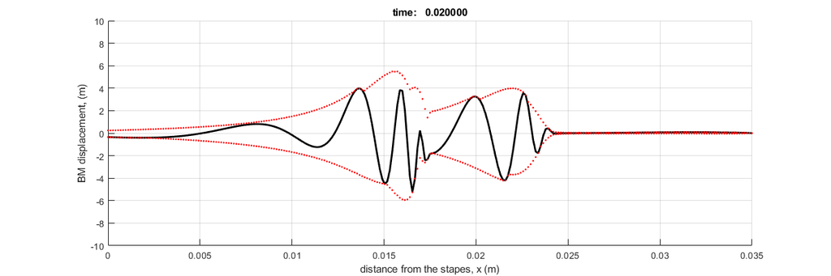

```matlab
%plot native
close all; clear all; clc;
f = 2000; dt = 1/f/20; w=2*pi*f;
t = [0:dt:40/f]';
Ust = 1;
envelop = 0*t+1;
envelop(1:6/f/dt) = linspace(0,1,6/f/dt);
Ast = (-Ust*w*w*sin(w*t)-Ust*w*w/4*sin(w/2*t)).*envelop;
cochlea_model_2d_passive_neely_time(t,Ast,1);
```

[output not shown]

## Two-D Cochlear Model - Finite Element Scheme

Previously, we have solved the 2d cochlear model using the finite difference method, here we would develop a finite element scheme.

[figure not shown]

### Control equations

$$\frac{1}{c^2}\frac{\partial p}{\partial t}-\nabla^2 p=0$$

on Dirichlet boundary: $p=\bar{p}$

on Neumann boundary: $\nabla p\cdot \vec{n}=-\rho \vec{a}\cdot\vec{n}$ where $\vec{a}$ is acceleration.

### Frequency domain

$$\nabla^2 P - \frac{j\omega}{c^2}P = 0$$

on Dirichlet boundary: $P=\bar{P}$

on Neumann boundary: $\nabla P\cdot\vec{n}=\rho\omega^2 \vec{U}\cdot\vec{n}$ where $\vec{U}$ is the displacement amplitude.

### Weak form

$$ \int_\Omega \delta P \left( \nabla^2 P -\frac{j\omega}{c^2}P \right) \mathrm{d}\Omega = 0 $$

since $ \int_{\Omega} \delta P \cdot \nabla^{2} P d \Omega=\int_{\Omega} \nabla(\delta P \cdot \nabla P) \mathrm{d} \Omega - \int_{\Omega} \nabla \delta P \cdot \nabla P \mathrm{d} \Omega =\int_{\Gamma_{N}} \delta p \cdot(\nabla P \cdot \vec{n}) \mathrm{d} \Gamma-\int_{\Omega} \nabla \delta P \cdot \nabla P \mathrm{d} \Omega$ the weak form is $$ \int_{\Omega} \nabla \delta P \cdot \nabla P \mathrm{d} \Omega+\frac{j \omega}{c^{2}} \int_{\Omega} \delta P \cdot P \mathrm{d} \Omega=\int_{\Gamma_{N}} \delta P \cdot(\nabla P \cdot \vec{n}) \mathrm{d}\Gamma $$ where $$\int_{\Gamma_{N}} \delta P \cdot(\nabla P \cdot \vec{n}) \mathrm{d}\Gamma = \int_{\Gamma_{N}} \delta P \cdot(-\rho\omega^2 U_n) \mathrm{d}\Gamma$$

### Finite element matrices

Assume the shape function $N(x,y)=[N_1, N_2, N_3, N_4]$, thus we have

for the term $\int_\Omega \nabla\delta P\cdot \nabla P \mathrm{d}\Omega$: $D_e=N_{x}^T N_x+N_{y}^T N_y$,

for the term $\int_\Omega \nabla\delta P\cdot P\mathrm{d}\Omega$: $M_e = N^{T}N$.

for boundary conditions, at the input (stapes): $\int_{\Gamma_{N}} \delta P \cdot(-\rho\omega^2 U_n) \mathrm{d}\Gamma$: $-\rho\omega^2 U_{stapes}\cdot H^T$

for boundary conditions, on the BM (SV): $\int_{\Gamma_{N}} \delta P \cdot(+\rho\omega^2 U_{BM}) \mathrm{d}\Gamma$ $$ \rho\omega^2 H^T H \left[\begin{array}{c}U_{BM1} \\ U_{BM2}\end{array}\right] = \rho\omega^2 H^T H \left [ \begin{array}{cccc} \frac{1}{Z(x_1)}&-\frac{1}{Z(x_1)}&0&0 \\ 0&0&\frac{1}{Z(x_2)}&-\frac{1}{Z(x_2)}\end{array} \right ] \cdot \left\{ \begin{array}{c} P_{ST1}\\P_{SV1}\\P_{ST2}\\P_{SV2}\end{array}\right\}$$

for boundary conditions, on the BM (ST): $\int_{\Gamma_{N}} \delta P \cdot(-\rho\omega^2 U_{BM}) \mathrm{d}\Gamma$ $$ -\rho\omega^2 H^T H \left[\begin{array}{c}U_{BM1} \\ U_{BM2}\end{array}\right] = -\rho\omega^2 H^T H \left [ \begin{array}{cccc} \frac{1}{Z(x_1)}&-\frac{1}{Z(x_1)}&0&0 \\ 0&0&\frac{1}{Z(x_2)}&-\frac{1}{Z(x_2)}\end{array} \right ] \cdot \left\{ \begin{array}{c} P_{ST1}\\P_{SV1}\\P_{ST2}\\P_{SV2}\end{array}\right\}$$

**The program `cochlea_model_2d_create_mesh.m` create a .mat file to store the mesh information**

```matlab
%%file cochlea_model_2d_create_mesh.m
function cochlea_model_2d_create_mesh(file)
    %% theis function try to create a 2D mesh as ADINA
    L = 0.035; HaSV = 0.001; HbSV = 0.0005; HaST = 0.001; HbST = 0.0005;
    Heli = 0.0005;
    % definition of points
    points.loc=[0,-HaST;        % point 1
                0,-0.00005;            % point 2
                0,0.00005;            % point 3
                0,HaSV;         % point 4
                L,-HbST;        % point 5
                L,0;            % point 6
                L,HbST;         % point 7
                L+Heli,-HbST;   % point 8
                L+Heli, 0;      % point 9
                L+Heli, HbSV];  % point 10
    lines.point=[1,5;  % line 1
                2,6;    % line 2
                3,6;    % line 3
                4,7;    % line 4
                5,8;    % line 5
                6,9;    % line 6
                7,10;   % line 7
                1,2;    % line 8
                5,6;    % line 9
                8,9;    % line 10
                3,4;    % lien 11
                6,7;    % line 12
                9,10];  % line 13
    surfs.line=[1,9,2,8;   % surf 1
                3,12,4,11;  % surf 2
                5,10,6,9;   % surf 3
                6,13,7,12]; % surf 4
    lines.ori = zeros(size(lines.point,1),1);
    surfs.ori = 0*surfs.line;
    points.no= size(points.loc,1);
    lines.no = size(lines.point,1);
    surfs.no = size(surfs.line,1);
    % divisions should be of same length of no. of lines
    lines.division =[256,256,256,256,5,5,5,10,10,10,10,10,10];
    %% analyze the geometry
    % check for line and points
    points.used = zeros(points.no,1);
    for ii = 1:lines.no
        points.used(lines.point(ii,:)) = points.used(lines.point(ii,:))+1;
    end
    if ~isempty(find(points.used<=1))
        fprintf('not all points been used !\n');
    end
    % check for surf and lines
    lines.used = zeros(lines.no,1);
    for ii = 1:surfs.no
        lines.used(surfs.line(ii,:))=lines.used(surfs.line(ii,:))+1;
    end
    if ~isempty(find(lines.used<1))
        fprintf('not all lines been used !\n');
    end
    % check for surf lines orientation
    for kk = 1:surfs.no
        tmp = surfs.line(kk,:);
        pts = lines.point(tmp,:);
        pts = [pts;pts(1,:)];
        for ii = 1:length(tmp)
            n11 = pts(ii,1); n12 = pts(ii,2);
            n21 = pts(ii+1,1); n22 = pts(ii+1,2);
            if n12 == n21 || n12 == n22
                surfs.ori(kk,ii) = 1;
                lines.ori(tmp(ii)) = 1;
            end
            if n11 == n21 || n11 == n22
                surfs.ori(kk,ii) = -1;
                lines.ori(tmp(ii)) = -1;
                pts(ii,1:2) = pts(ii,2:-1:1);
            end
        end
        if ~isempty(find(surfs.ori(kk,:)==0))
            fprintf('problems in surfs orientation\n');
        end
        for ii = 1:length(tmp)-1
            L1 = points.loc(pts(ii,2),:)-points.loc(pts(ii,1),:);
            L2 = points.loc(pts(ii+1,2),:)-points.loc(pts(ii+1,1),:);
            if L1(1)*L2(2)-L1(2)*L2(1)<=0
                fprintf('problems in surfs orientation, negtive\n');
            end
        end
    end

    %% Check for mapping
    for kk = 1:surfs.no
        tmp = surfs.line(kk,:);
        if lines.division(tmp(1))~=lines.division(tmp(3)) ...
            || lines.division(tmp(2))~=lines.division(tmp(4))
            fprintf('problems in surfs (surf. %d) mapping \n',kk);
            return;
        end
    end

    %% evaluation
    nnod = 0;
    nele = 0;
    for kk = 1:surfs.no
        tmp = surfs.line(kk,:);
        M = lines.division(tmp(1));
        N = lines.division(tmp(2));
        nnod = nnod+(M+1)*(N+1);
        nele = nele+M*N;
    end

    %% mesh
    nod = zeros(nnod,2);
    ele = zeros(nele,4);
    % points mesh
    nodkk = 0; elekk = 0;
    nod(nodkk+(1:points.no),:) = points.loc;
    points.nodid = nodkk+(1:points.no);
    nodkk = nodkk + points.no;

    % line mesh
    for kk = 1:lines.no
        p1 = lines.point(kk,1);
        p2 = lines.point(kk,2);
        if lines.ori(kk) == -1;
            tmp = p1; p1 = p2; p2 = tmp;
        end
        N = lines.division(kk);
        loc1 = points.loc(p1,:);
        loc2 = points.loc(p2,:);
        nod(nodkk+(1:N-1),:) = loc1+(1:N-1)'*(loc2-loc1)/N;
        lines.nodid{kk} = [p1 nodkk+(1:N-1) p2];
        nodkk = nodkk + N-1;
    end

    % sufrace mesh
    for kk = 1:surfs.no
        tmp = surfs.line(kk,:);
        L1 = tmp(1); L2 = tmp(2); L3 = tmp(3); L4 = tmp(4);
        L1nod = lines.nodid{L1};
        L2nod = lines.nodid{L2};
        L3nod = lines.nodid{L3};
        L4nod = lines.nodid{L4};
        if( surfs.ori(kk,1)*lines.ori(L1) == -1) L1nod = L1nod(end:-1:1); end
        if( surfs.ori(kk,2)*lines.ori(L2) == -1) L2nod = L2nod(end:-1:1); end
        if( surfs.ori(kk,3)*lines.ori(L3) ==  1) L3nod = L3nod(end:-1:1); end
        if( surfs.ori(kk,4)*lines.ori(L4) ==  1) L4nod = L4nod(end:-1:1); end
        M = length(L1nod); N = length(L2nod);

        nodtopo = zeros( M,N );
        nodtopo(:,1) = L1nod;
        nodtopo(:,N) = L3nod;
        nodtopo(1,:) = L4nod;
        nodtopo(M,:) = L2nod;
        for jj = 2:N-1
            a1 = nod(L4nod(jj),:);
            a2 = nod(L2nod(jj),:);
            a = a2-a1;
            for ii = 2:M-1
                b1 = nod(L1nod(ii),:);
                b2 = nod(L3nod(ii),:);
                b = b2-b1;
                c = b1-a1;
                t = c(1)*b(2)-c(2)*b(1);
                t = t/(a(1)*b(2)-a(2)*b(1));
                nod(nodkk+1,:) = a1+t*a;
                nodkk = nodkk + 1;
                nodtopo(ii,jj) = nodkk;
            end
        end

        for jj = 1:N-1
            for ii = 1:M-1
                ele(elekk+1,:) = [nodtopo(ii,jj),nodtopo(ii+1,jj),nodtopo(ii+1,jj+1),nodtopo(ii,jj+1)];
                elekk = elekk+1;
            end
        end
    end
    nod = nod(1:nodkk,:);
    ele = ele(1:elekk,:);
    figure(1); hold on;
    patch('Faces',ele,'Vertices',nod,'facecolor','g');
    figure(2); hold on;
    for ii = 1:lines.no
        tmp = points.loc(lines.point(ii,:),:);
        if lines.used(ii) == 1
            plot(tmp(:,1),tmp(:,2),'bo-','linewidth',2);
            mid = (tmp(1,:)+tmp(2,:))/2;
            text(mid(1),mid(2),num2str(ii),'color','r');
        else
            plot(tmp(:,1),tmp(:,2),'g-','linewidth',1);
        end
    end
    save(file,'nod','ele','lines');
end
```

```
Created file 'C:\Users\RenLi\__model_cochlea\cochlea_model_2d_create_mesh.m'.
```

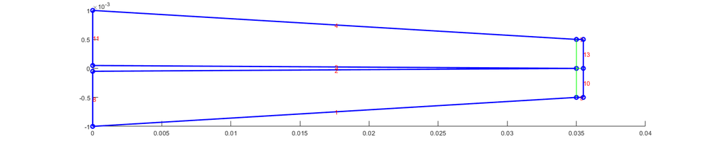

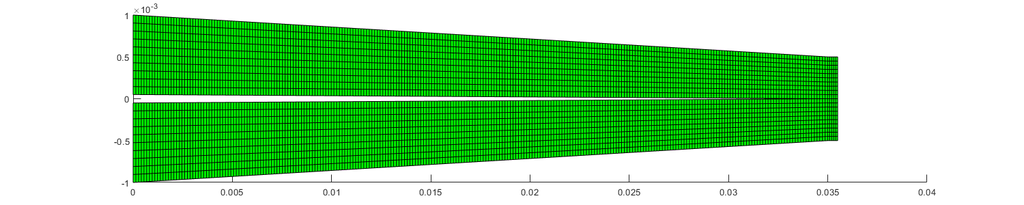

```matlab
%plot inline --size 1500,300
cochlea_model_2d_create_mesh('mesh.mat');
```

```matlab
%%file cochlea_model_2d_passive_finite_element.m
function [nod,ele,P,Pup,Pdn,U] = cochlea_model_2d_passive_finite_element(freq)
load('mesh.mat');
omega = 2*pi*freq;
c = 1430; rho=1000;
Ustapes = 1;

bc1 = lines.nodid{8}';
bc1 = [bc1 0*bc1];
bc2 = lines.nodid{9}';
bc2tmp = zeros(length(bc2)-1,3);
for ii = 1:length(bc2)-1
    bc2tmp(ii,1) = bc2(ii);
    bc2tmp(ii,2) = bc2(ii+1);
    bc2tmp(ii,3) = -rho*omega^2*Ustapes;
end
bc2 = bc2tmp;

% coupled bc
doline = lines.nodid{2}'; doline = doline(end:-1:1);
upline = lines.nodid{3}';
bc3tmp_1 = zeros(length(upline)-1,6);
for ii = 1:size(bc3tmp_1,1)
    bc3tmp_1(ii,1) = upline(ii);   % n1sv
    bc3tmp_1(ii,2) = upline(ii+1); % n2sv
    bc3tmp_1(ii,3) = doline(ii);   % n1st
    bc3tmp_1(ii,4) = doline(ii+1); % n2st
    x = nod(upline(ii),1);
    stiffness = 2e10*exp(-270*x);
    mass      = 1.5;
    damping   = 2*0.02*sqrt(stiffness*mass);
    Z1        = stiffness-mass*omega^2+1i*omega*damping;
    x = nod(upline(ii+1),1);
    stiffness = 2e10*exp(-270*x);
    mass      = 1.5;
    damping   = 2*0.02*sqrt(stiffness*mass);
    Z2        = stiffness-mass*omega^2+1i*omega*damping;
    bc3tmp_1(ii,5) = Z1;
    bc3tmp_1(ii,6) = Z2;
end
bc3 = bc3tmp_1;
Z = zeros(length(upline),1);
for ii = 1:length(upline)
    x = nod(upline(ii),1);
    stiffness = 2e10*exp(-270*x);
    mass      = 1.5;
    damping   = 2*0.02*sqrt(stiffness*mass);
    Z(ii)     = stiffness-mass*omega^2+1i*omega*damping;
end

% the main program
[nnod,ndim] = size(nod);
[nele,etyp] = size(ele);
space = nele*etyp^2;
fprintf(1,'number of unknowns:              %10d\n',nnod);
fprintf(1,'elements in the stiffness matrix:%10d\n',space);
space = floor(space*2);

% gauss integral set up
gauss2 = [ -0.577350269189626 0.577350269189626];
weight2= [ 1.0000000000000000 1.000000000000000];
for ii = 1:2
for jj = 1:2
    xi = gauss2(ii);
    et = gauss2(jj);
    W_all(:,ii,jj)   =[ 0.25*(xi-1)*(et-1);
                       -0.25*(xi+1)*(et-1);
                        0.25*(xi+1)*(et+1);
                       -0.25*(xi-1)*(et+1) ];
    Wxi_all(:,ii,jj) =[ 0.25*(et-1);
                       -0.25*(et-1);
                        0.25*(et+1);
                       -0.25*(et+1) ];
    Wet_all(:,ii,jj) =[ 0.25*(xi-1);
                       -0.25*(xi+1);
                        0.25*(xi+1);
                       -0.25*(xi-1) ];
    Weight_all(ii,jj)= weight2(ii)*weight2(jj);
end
end
% assemble
coe = 1i*omega/c^2;
Kidx  = zeros(space,1);
Kjdx  = zeros(space,1);
Ktmp  = zeros(space,1); Kflag = 0;
Ftmp  = zeros(nnod,1);
for ee = 1:nele
    elee = ele(ee,:);
    node = nod(elee,:);
    Ke = zeros(etyp,etyp); De = Ke; Me = Ke;
    Fe = zeros(etyp,1);
    for ii = 1:2
        for jj = 1:2
            W(:,1)=W_all(:,ii,jj);
            Wxi(:,1)=Wxi_all(:,ii,jj);
            Wet(:,1)=Wet_all(:,ii,jj);
            xy_xiet = node'*[Wxi,Wet];
            jacobi = det(xy_xiet);
            xiet_xy = inv(xy_xiet);
            A = [Wxi Wet]*xiet_xy;
            Wx = A(:,1);Wy = A(:,2);
            De = De + jacobi*Weight_all(ii,jj)*(Wx*Wx'+Wy*Wy');
            Me = Me + jacobi*Weight_all(ii,jj)*(W*W');
            Fe = Fe + 0; % no body force
            Ke = Ke + De + coe*Me;
        end
    end
    list    = elee';
    Kidx(Kflag+1:Kflag+etyp^2) = [list;list;list;list];
    Kjdx(Kflag+1:Kflag+etyp^2) = [list list list list]';
    Ktmp(Kflag+1:Kflag+etyp^2) = Ke(:); Kflag = Kflag + etyp^2;
    Ftmp(list) = Ftmp(list) + Fe(:);
end
% 2rd class boundry conditions
for ii = 1:size(bc2,1)
    n1 = bc2(ii,1); n2 = bc2(ii,2);
    h  = bc2(ii,3);
    xy1 = nod(n1,:); xy2 = nod(n2,:); L = norm(xy2-xy1);
    Fe = h*[0.5;0.5]*L;
    list = [n1;n2];
    Ftmp(list) = Ftmp(list)+Fe(:);
end
% 3rd class boundry conditions / special for bm
for ii = 1:size(bc3,1)
    n1sv = bc3(ii,1); n2sv = bc3(ii,2);
    n1st = bc3(ii,3); n2st = bc3(ii,4);
    Z1 = bc3(ii,5); Z2 = bc3(ii,6);
    % for the SV part
    xy1 = nod(n1sv,:); xy2 = nod(n2sv,:); L = norm(xy1-xy2);
    Ke = [2,1;1,2]/6*L*rho*omega^2*[1/Z1,-1/Z1,0,0; 0,0, 1/Z2,-1/Z2];
    Kidx(Kflag+1:Kflag+8) = [n1sv n2sv n1sv n2sv n1sv n2sv n1sv n2sv];
    Kjdx(Kflag+1:Kflag+8) = [n1st n1st n1sv n1sv n2st n2st n2sv n2sv];
    Ktmp(Kflag+1:Kflag+8) = Ke(:); Kflag = Kflag + 8;
    % for the ST part
    xy1 = nod(n1st,:); xy2 = nod(n2st,:); L = norm(xy1-xy2);
    Ke = -[2,1;1,2]/6*L*rho*omega^2*[1/Z1,-1/Z1,0,0; 0,0, 1/Z2,-1/Z2];
    Kidx(Kflag+1:Kflag+8) = [n1st n2st n1st n2st n1st n2st n1st n2st];
    Kjdx(Kflag+1:Kflag+8) = [n1st n1st n1sv n1sv n2st n2st n2sv n2sv];
    Ktmp(Kflag+1:Kflag+8) = Ke(:); Kflag = Kflag + 8;
end
Kstiff = sparse( Kidx(1:Kflag), Kjdx(1:Kflag), Ktmp(1:Kflag), nnod,nnod);
F      = Ftmp;

% 1rd class boundary conditions
dbc = bc1;
largevalue              = 1.0e8;
indexI                  = zeros(size(dbc,1),1);
KBCtmp                  = zeros(size(dbc,1),1);
Kdiag                   = diag(Kstiff);
Kii                     = Kdiag(dbc(:,1));
for ii = 1:size(dbc,1)
    bcdofs              = dbc(ii,1);
    bcvalu              = dbc(ii,2);
    indexI(ii)          = bcdofs;
    KBCtmp(ii)          = -Kii(ii) + Kii(ii) * largevalue;
end
F(dbc(:,1),1) = largevalue*Kii.*dbc(:,2);
KBC = sparse(indexI,indexI,KBCtmp,size(Kstiff,1),size(Kstiff,2) );
Kstiff = Kstiff + KBC;

% solver
P = full(Kstiff\F);
Pup = P(upline);
Pdn = P(doline);
U   = (Pdn-Pup)./Z;
end
```

```
Created file 'C:\Users\RenLi\__model_cochlea\cochlea_model_2d_passive_finite_element.m'.
```

```
number of unknowns:                    5758
elements in the stiffness matrix:     83520
```

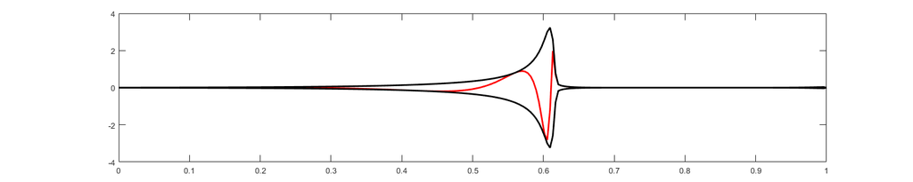

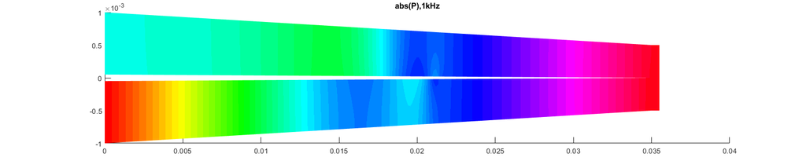

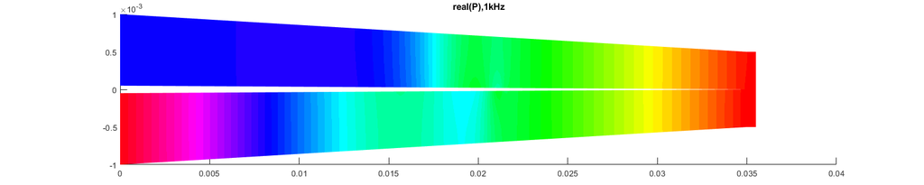

```matlab
%plot inline --size 1500,300
[nod,ele,P,Pup,Pdn,U]=cochlea_model_2d_passive_finite_element(1000);
figure(1); patch('Faces',ele,'Vertices',nod,'FaceVertexCData',real(P),'FaceColor','interp','edgecolor','none');
title('real(P),1kHz'); colormap('hsv')
figure(2); patch('Faces',ele,'Vertices',nod,'FaceVertexCData',abs(P),'FaceColor','interp','edgecolor','none');
title('abs(P),1kHz'); colormap('hsv')
figure(3); plot(linspace(0,1,length(U)),real(U),'r-','linewidth',2); hold on;
plot(linspace(0,1,length(U)), abs(U),'k-','linewidth',2);
plot(linspace(0,1,length(U)),-abs(U),'k-','linewidth',2);
```

```
number of unknowns:                    5758
elements in the stiffness matrix:     83520
```

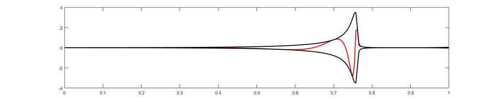

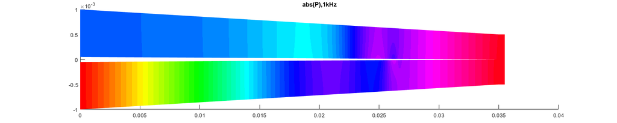

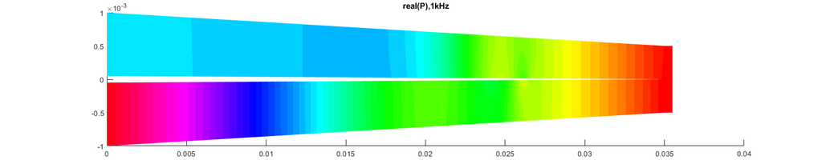

```matlab
%plot inline --size 1500,300
[nod,ele,P,Pup,Pdn,U]=cochlea_model_2d_passive_finite_element(500);
figure(1); patch('Faces',ele,'Vertices',nod,'FaceVertexCData',real(P),'FaceColor','interp','edgecolor','none');
title('real(P),1kHz'); colormap('hsv')
figure(2); patch('Faces',ele,'Vertices',nod,'FaceVertexCData',abs(P),'FaceColor','interp','edgecolor','none');
title('abs(P),1kHz'); colormap('hsv')
figure(3); plot(linspace(0,1,length(U)),real(U),'r-','linewidth',2); hold on;
plot(linspace(0,1,length(U)), abs(U),'k-','linewidth',2);
plot(linspace(0,1,length(U)),-abs(U),'k-','linewidth',2);
```

```
number of unknowns:                    5758
elements in the stiffness matrix:     83520
number of unknowns:                    5758
elements in the stiffness matrix:     83520
number of unknowns:                    5758
elements in the stiffness matrix:     83520
number of unknowns:                    5758
elements in the stiffness matrix:     83520
number of unknowns:                    5758
elements in the stiffness matrix:     83520
number of unknowns:                    5758
elements in the stiffness matrix:     83520
```

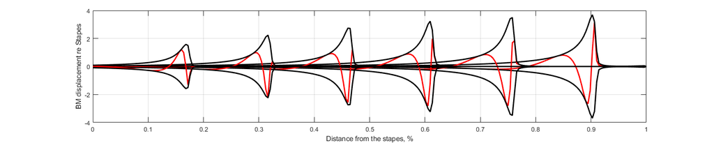

```matlab
%plot inline --size 1500,300
figure(1);
for freq = [250,500,1000,2000,4000,8000]
    [nod,ele,P,Pup,Pdn,U]=cochlea_model_2d_passive_finite_element(freq);
    figure(1)
    plot(linspace(0,1,length(U)),real(U),'r-','linewidth',2); hold on;
    plot(linspace(0,1,length(U)), abs(U),'k-','linewidth',2);
    plot(linspace(0,1,length(U)),-abs(U),'k-','linewidth',2);
end
grid on;
xlabel('Distance from the stapes, %');
ylabel('BM displacement re Stapes');
```